# 01-Statistics

**To use statistics in python we can use the statistics module**

- import statistics as stats

```python
import statistics as stats
```

**Let us try to find the measures of central Location/Tendency**

- mean - calculate the mean of the integer numbers

```python
data = list(range(11))
print(data)
print('Mean of the data is {} '.format(stats.mean(data)))
```

```
[0, 1, 2, 3, 4, 5, 6, 7, 8, 9, 10]
Mean of the data is 5
```

```python
data = [1.2,2.2,3.2,4.2,5.2]
print(data)
print('Mean of the floating data points is {}'.format(stats.mean(data)))
```

```
[1.2, 2.2, 3.2, 4.2, 5.2]
Mean of the floating data points is 3.2
```

- fmean - Converts all the numbers to flaoting point numbers and computes the mean

```python
data = list(range(11))
print(data)
print('Mean of the data is {} '.format(stats.fmean(data)))
```

```
[0, 1, 2, 3, 4, 5, 6, 7, 8, 9, 10]
Mean of the data is 5.0
```

- Converting string representation of decimal and computing mean
- Add weights to the values and compute the mean

```python
# Supported from 3.11 weigths are also supported for computing mean
grades = [85, 92, 83, 91]

weights = [0.20, 0.20, 0.30, 0.30]

stats.fmean(grades, weights)
```

[output not shown]

```python
from decimal import Decimal as D

print('Mean of the decimal values are {}'.format(stats.mean([D("0.5"), D("0.75"), D("0.625"), D("0.375")])))
```

```
Mean of the decimal values are 0.5625
```

```python
import statistics as stats
scores = [10,12,13,11,9,14,15,17,98]
print('Mean of the scores is {}'.format(stats.mean(scores)))
salary = [5000,5500,6500,7000,7500,8000,8500,1000000000]
print('Mean of the salary is {}'.format(stats.mean(salary)))
```

```
Mean of the scores is 22.11111111111111
Mean of the salary is 125006000
```

**Note** -

The `mean` is strongly affected by outliers and is not necessarily a typical example of the data points. For a more robust, although less efficient, measure of central tendency,see `median()`

**Goemetric mean for numbers**

$$ a_1,a_2,a_3.....a_n $$

is given by

$$ (a_1*a_2*a_3*....*a_n)^\frac{1}{n}\\ $$

```python
stats.geometric_mean([54, 24, 36])
```

```
36.000000000000014
```

```python
# round function rounds of the geometric mean to the nearest decimal value
round(stats.geometric_mean([54, 24, 36]),9)
```

```
36.0
```

**Harmonic mean for numbers**

The harmonic mean is the reciprocal of the arithmetic `mean()` of the reciprocals of the data. For example, the harmonic mean of three values a, b and c will be equivalent to `3/(1/a + 1/b + 1/c)`. If one of the values is zero, the result will be zero

```python
stats.harmonic_mean([40, 60, 80])
```

```
55.38461538461538
```

- `median` the median (middle value) of numeric data, using the common “mean of middle two” method. If data is empty, StatisticsError is raised

```python
stats.median([1,3,5])
```

```
3
```

- When the number of data points is even, the median is interpolated by taking the average of the two middle values:

```python
stats.median([1, 3, 5, 7])
```

```
4.0
```

- `median_low` - Return the low median of numeric data. If data is empty, StatisticsError is raised.
  - The low median is always a member of the data set.
  - When the number of data points is odd, the middle value is returned. When it is even, the smaller of the two middle values is returned.

```python
stats.median_low([1, 3, 5])
```

```
3
```

```python
stats.median_low([1, 3, 5, 7])
```

```
3
```

- `median_high`
  - Return the high median of data. If data is empty, StatisticsError is raised.
  - The high median is always a member of the data set.
  - When the number of data points is odd, the middle value is returned. When it is even, the larger of the two middle values is returned.

```python
stats.median_high([1, 3, 5])
```

```
3
```

```python
stats.median_high([1, 3, 5, 7])
```

```
5
```

- `mode()`
  - return the single most common data point from discrete or nominal data.
  - The mode (when it exists) is the most typical value and serves as a measure of central location.
  - If there are multiple modes with the same frequency, returns the first one encountered in the data.
  - `mode` assumes discrete data and returns a single value.

```python
stats.mode([11, 11, 12, 13, 13, 13, 13, 14])
```

```
13
```

```python
stats.mode(["apple", "banana", "banana", "apple", "mango", "apple", "apple"])
```

```
'apple'
```

- `pstdev` - Return the population standard deviation

```python
stats.pstdev([1.5, 2.5, 2.5, 2.75, 3.25, 4.75])
```

```
0.986893273527251
```

- `pvariance` - Return the population variance of data, a non-empty sequence or iterable of real-valued numbers. Variance, or second moment about the mean, is a measure of the variability

```python
data = [0.0, 0.25, 0.25, 1.25, 1.5, 1.75, 2.75, 3.25]
stats.pvariance(data)
```

```
1.25
```

If you have already calculated the mean of your data, you can pass it as the optional second argument mu

```python
mu = stats.mean(data)
stats.pvariance(data, mu)
```

```
1.25
```

- `stdev` - Return the sample standard deviation (the square root of the sample variance)

```python
stats.stdev([1.5, 2.5, 2.5, 2.75, 3.25, 4.75])
```

```
1.0810874155219827
```

- `variance` - Return the sample variance of data, an iterable of at least two real-valued numbers. Variance, or second moment about the mean, is a measure of the variability (spread or dispersion) of data.

```python
data = [2.75, 1.75, 1.25, 0.25, 0.5, 1.25, 3.5]
stats.variance(data)
```

```
1.3720238095238095
```

- `quantiles` - Divide data into n continuous intervals with equal probability. Returns a list of n - 1 cut points separating the intervals.

Set n to 4 for quartiles (the default).

```python
data = [105, 129, 87, 86, 111, 111, 89, 81, 108, 92, 110,

        100, 75, 105, 103, 109, 76, 119, 99, 91, 103, 129,

        106, 101, 84, 111, 74, 87, 86, 103, 103, 106, 86,

        111, 75, 87, 102, 121, 111, 88, 89, 101, 106, 95,

        103, 107, 101, 81, 109, 104]
```

```python
[round(q, 1) for q in stats.quantiles(data)]
```

```
[87.0, 102.5, 108.2]
```

```python
[round(q, 1) for q in stats.quantiles(data, n=5)]
```

```
[86.2, 99.4, 103.6, 109.8]
```

- `covariance(x,y)`
  - Return the sample covariance of two inputs x and y. Covariance is a measure of the joint variability of two inputs.

```python
x = [1, 2, 3, 4, 5, 6, 7, 8, 9]

y = [1, 2, 3, 1, 2, 3, 1, 2, 3]
stats.covariance(x, y)
```

```
0.75
```

- `correlation` Pearson’s correlation coefficient r takes values between -1 and +1. It measures the strength and direction of the linear relationship, where +1 means very strong, positive linear relationship, -1 very strong, negative linear relationship, and 0 no linear relationship

```python
x = [1, 2, 3, 4, 5, 6, 7, 8, 9]

y = [9, 8, 7, 6, 5, 4, 3, 2, 1]
print('Correlation between x and x is {}'.format(stats.correlation(x, x)))
```

```
Correlation between x and x is 1.0
```

```python
x = [1, 2, 3, 4, 5, 6, 7, 8, 9]

y = [9, 8, 7, 6, 5, 4, 3, 2, 1]
print('Correlation between x and y is {}'.format(stats.correlation(x, y)))
```

```
Correlation between x and y is -1.0
```

`quantiles` - Quantiles for the various values

```python
c = [70, 85, 90, 98, 104, 105, 107]
```

```python
q = stats.quantiles(c)
```

```python
q
```

```
[85.0, 98.0, 105.0]
```

```python
q[2] - q[0]
```

```
20.0
```

```python
import matplotlib.pyplot as plt
import seaborn as sns
```

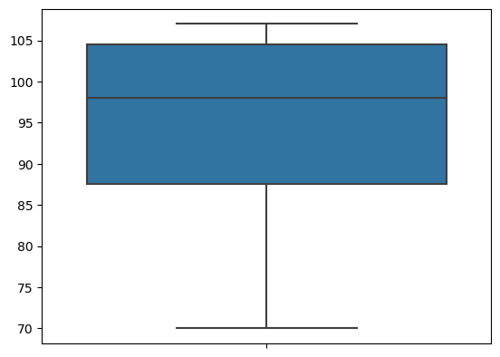

```python
sns.boxplot(y = c)
plt.show()
```

- `zscore` - Compute the Standard Score describing x in terms of the number of standard deviations above or below the mean of the normal distribution: `(x - mean) / stdev`

```python
import statistics as stats
mean = 7
standard_deviation = 1.3

zscore = stats.NormalDist(mean, standard_deviation).zscore(5)
print(zscore)

print('-------')
print(stats.NormalDist(mean, standard_deviation).zscore(7))


print('-------')
print(stats.NormalDist(mean, standard_deviation).zscore(11))
```

```
-1.5384615384615383
-------
0.0
-------
3.0769230769230766
```

```python
## import scipy stats module to calculate the z-scores for the various values
import scipy.stats as stats
values = [4,5,6,6,6,7,8,12,13,13,14,18]

zscores = stats.zscore(values)
print(zscores)
```

```
[-1.2493901  -1.01512945 -0.78086881 -0.78086881 -0.78086881 -0.54660817
 -0.31234752  0.62469505  0.85895569  0.85895569  1.09321633  2.0302589 ]
```